# QGIS Training

# 7 Setting up the survey

#### Learning objectives

- learn what a QGIS package is
- how to set up a QGIS package and the QGIS survey on your laptop

## How does QGIS work?

We learnt to collect data on QField but how do you create the survey in the first place?

**1.** Create a new folder `qgis_training_example2` in the `Documents` section of your file explorer.

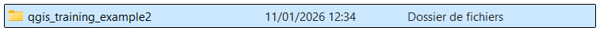

**2.** Create a subfolder named `layers` in the folder you created at the previous step.

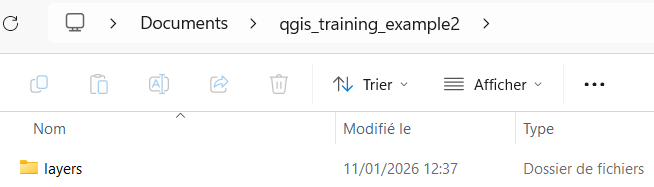

**3.** Download the following files: Tree flags, Diameter values, POM values, Style, Fieldsheet.

**4.** Copy them in the `layers`subfolder you created at step 2.

[figure not shown]

**5.** Open QGIS.

**6.** Click on the *Projet* menu and then *Enregistrer sous…*.

[figure not shown]

**7.** Save your project under the name `qgis_training_example2.qgz` in the `qgis_training_example2` folder created at step 1.

[figure not shown]

**8.** Click on the *Projet* menu and then *Propriétés*.

[figure not shown]

**9.** In the *Général* tab, verify that length and area units follow the metric system.

[figure not shown]

**10.** Click on the *Couche* menu, then *Ajouter une couche* and finally *Ajouter une couche de texte délimité…*.

[figure not shown]

[figure not shown]

**12.** In *Format de fichier*, select the right separator. The table columns should be conserved, you can check in the section *Echantillon de données*. Verify that *Détecter les types de champs* is unticked. Verify that *Pad de géométrie (juste la table)* is ticked.

[figure not shown]

**13.** Click on *Ajouter*.

**14.** Repeat for all the *.csv* files in the `layers` subfolder.

[figure not shown]

**16.** Select `treesheet_training.gpkg` from the `layers` subfolder in the pop-up window.

[figure not shown]

**17.** Click on the *Connecter* button, then on *treesheet_training* (highlighted in blue) and finally on *Ajouter*.

[figure not shown]

**18.** Click right on the *treesheet_training* layer and then click on *Propriétés*.

[figure not shown]

**19.** Click on *Style* in the left bottom corner of the pop-up window (it does not matter in which tab) and then click on *Charger le style*.

[figure not shown]

**20.** Click on the three dots symbol in the pop-up window.

[figure not shown]

**21.** Select `training_style.qml` and then click on *Ouvrir*.

[figure not shown]

**22.** You are now back to the previous pop-up window where you need to click on *Charger le style*.

[figure not shown]

**23.** You are back to the *Propriétés* window, click on *Ok*.

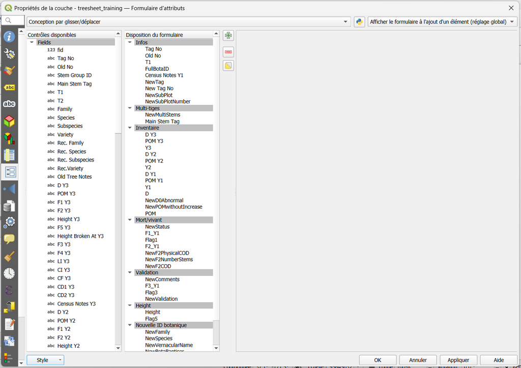

**24.* Your now have to format your QGIS project for export: click on *Extensions*, then *QFieldSync*, and finally *Configurer le projet actuel*.

[figure not shown]

**25.* Go to *Export par câble* and check that every layer is classified as *Copy* in the *Action* section.

[figure not shown]

**26.** Click on *Extensions*, then *QFieldSync*, and finally *Paquet pour QField*.

[figure not shown]

**27.** Verify that the QField package will be stored as closest as your computer root as possible, then click on *Créer*.

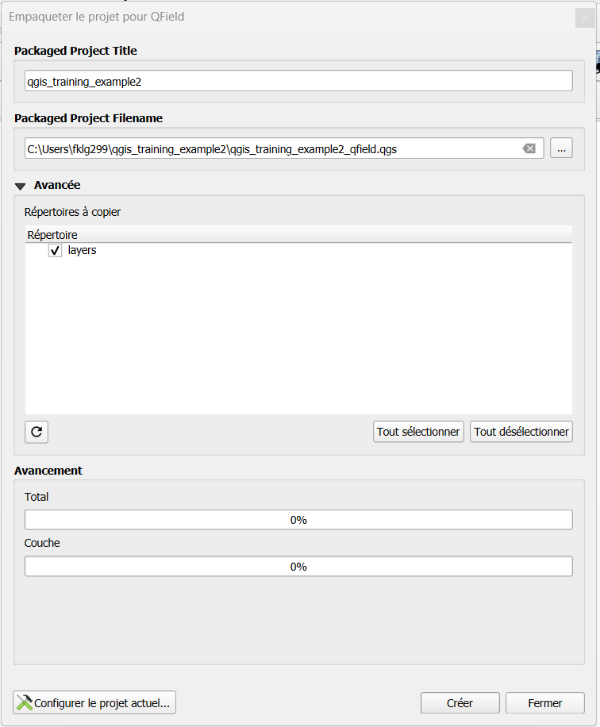

**28.** Connect the tablet to your laptop and allow sharing of the tablet data, then go to your QField package location.

**29.** Copy the QField package and paste it at the root of your tablet.

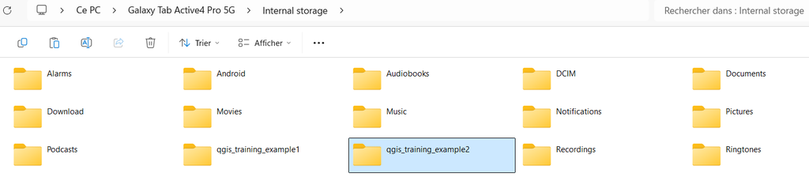

You can now proceed open your project on the tablet (see Using QField survey for a reminder on how to proceed) and collect data!

# 8 You’ve got data!

#### Learning objectives

- Get the data safely onto your device or hard drive
- Understand what the output of the data is

So, you’ve successfully made a QGIS survey and collected your data. Now onto potentially the most important step of this entire process: making sure that you don’t lose all of the data that you just collected.

## Saving data onto a hard drive

You spent a tough day collecting data in the field, it is now time to store this data in several places to mitigate risks.

**1.** Open the Play Store, type ‘fv file manager app’ in the research bar and click on *Install* in the right panel.

[figure not shown]

[figure not shown]

**3.** In the notification pop-up, click *Don’t allow*.

[figure not shown]

**4.** Click *Do not consent* in the personal data use pop-up window.

[figure not shown]

**5.** Click on the *Files* symbol in the right-hand side.

**6.** Connect your hard drive.

**7.** Go to your hard drive location, here *T7 Shield*. Click on the three verticals dots in the right-hand corner and select *New folder* in the drop-down menu.

[figure not shown]

**8.** Give a name with today’s date in YYYYMMDD format, for instance *20260112_sauvegarde*. Click *OK*.

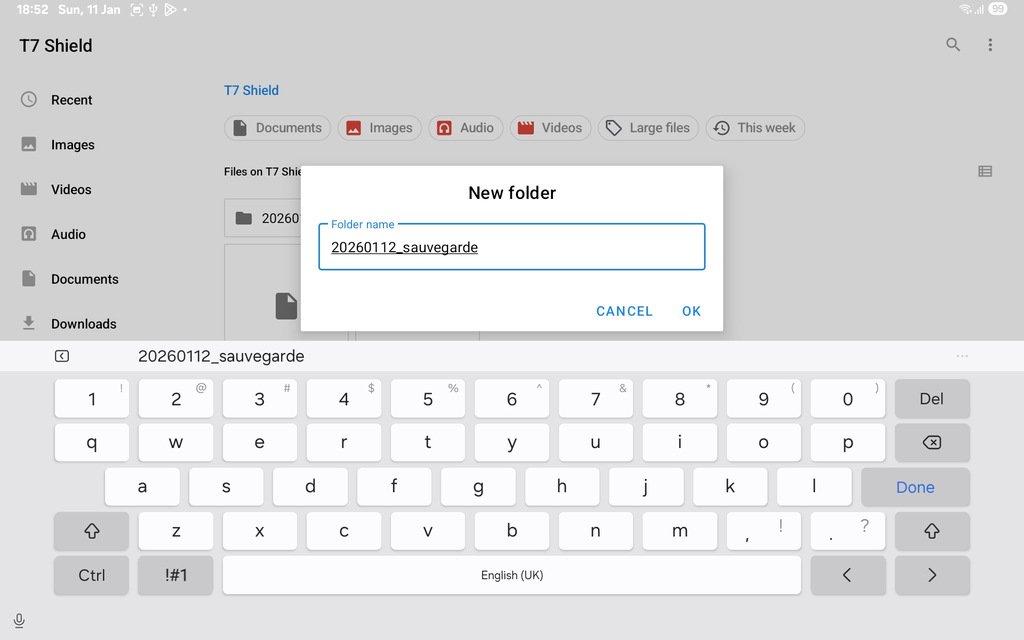

**9.** Click on *Galaxy Tab Active4 Pro* on the left panel.

[figure not shown]

**10.** Click on *Android* folder.

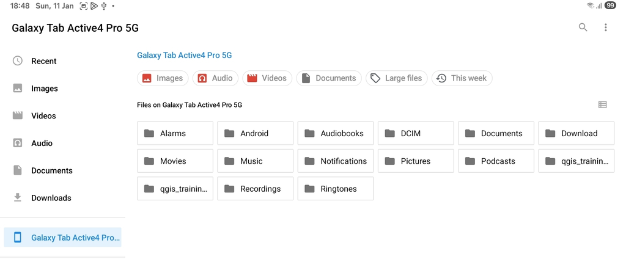

**11.** Click on *data* folder.

[figure not shown]

**12.** Click on *ch.opengis.qfield* folder.

[figure not shown]

**13.** Click on *files* folder.

[figure not shown]

**14.** Click on *Imported projects* folder.

[figure not shown]

**15.** Select `qgis_training_example2` by keeping your finger on it, click on the three dots in the top right corner and click on *Copy to*.

[figure not shown]

[figure not shown]

**17.** Your day’s work is now safely stored in the hard drive. This step must be repeated every night and on a second hard drive.

[figure not shown]